# African Financial Crisis

## Preliminary Wrangling

> This Dataset specifically focuses on the Banking, Debt, Financial, Inflation and Systemic Crises that occurred, from 1860 to 2014, in 13 African countries, including: Algeria, Angola, Central African Republic, Ivory Coast, Egypt, Kenya, Mauritius, Morocco, Nigeria, South Africa, Tunisia, Zambia and Zimbabwe.

```python
# import all packages and set plots to be embedded inline
import numpy as np
import pandas as pd
import matplotlib.pyplot as plt
import seaborn as sb
import scipy
%matplotlib inline
```

> Load in your dataset and describe its properties through the questions below. Try and motivate your exploration goals through this section.

```python
# Load in the dataset
df = pd.read_csv('african_crises.csv')
df.head(10)
```

|  | case | cc3 | country | year | systemic_crisis | exch_usd | domestic_debt_in_default | sovereign_external_debt_default | gdp_weighted_default | inflation_annual_cpi | independence | currency_crises | inflation_crises | banking_crisis |
| --- | --- | --- | --- | --- | --- | --- | --- | --- | --- | --- | --- | --- | --- | --- |
| 0 | 1 | DZA | Algeria | 1870 | 1 | 0.052264 | 0 | 0 | 0.0 | 3.441456 | 0 | 0 | 0 | crisis |
| 1 | 1 | DZA | Algeria | 1871 | 0 | 0.052798 | 0 | 0 | 0.0 | 14.149140 | 0 | 0 | 0 | no_crisis |
| 2 | 1 | DZA | Algeria | 1872 | 0 | 0.052274 | 0 | 0 | 0.0 | -3.718593 | 0 | 0 | 0 | no_crisis |
| 3 | 1 | DZA | Algeria | 1873 | 0 | 0.051680 | 0 | 0 | 0.0 | 11.203897 | 0 | 0 | 0 | no_crisis |
| 4 | 1 | DZA | Algeria | 1874 | 0 | 0.051308 | 0 | 0 | 0.0 | -3.848561 | 0 | 0 | 0 | no_crisis |
| 5 | 1 | DZA | Algeria | 1875 | 0 | 0.051546 | 0 | 0 | 0.0 | -20.924178 | 0 | 0 | 0 | no_crisis |
| 6 | 1 | DZA | Algeria | 1876 | 0 | 0.051867 | 0 | 0 | 0.0 | -1.769547 | 0 | 0 | 0 | no_crisis |
| 7 | 1 | DZA | Algeria | 1877 | 0 | 0.051867 | 0 | 0 | 0.0 | 29.116045 | 0 | 0 | 1 | no_crisis |
| 8 | 1 | DZA | Algeria | 1878 | 0 | 0.051948 | 0 | 0 | 0.0 | -1.492537 | 0 | 0 | 0 | no_crisis |
| 9 | 1 | DZA | Algeria | 1879 | 0 | 0.052029 | 0 | 0 | 0.0 | -16.831357 | 0 | 0 | 0 | no_crisis |

```python
df.shape
```

```
(1059, 14)
```

```python
df.info()
```

```
<class 'pandas.core.frame.DataFrame'>
RangeIndex: 1059 entries, 0 to 1058
Data columns (total 14 columns):
 #   Column                           Non-Null Count  Dtype
---  ------                           --------------  -----
 0   case                             1059 non-null   int64
 1   cc3                              1059 non-null   object
 2   country                          1059 non-null   object
 3   year                             1059 non-null   int64
 4   systemic_crisis                  1059 non-null   int64
 5   exch_usd                         1059 non-null   float64
 6   domestic_debt_in_default         1059 non-null   int64
 7   sovereign_external_debt_default  1059 non-null   int64
 8   gdp_weighted_default             1059 non-null   float64
 9   inflation_annual_cpi             1059 non-null   float64
 10  independence                     1059 non-null   int64
 11  currency_crises                  1059 non-null   int64
 12  inflation_crises                 1059 non-null   int64
 13  banking_crisis                   1059 non-null   object
dtypes: float64(3), int64(8), object(3)
memory usage: 116.0+ KB
```

```python
df.describe()
```

|  | case | year | systemic_crisis | exch_usd | domestic_debt_in_default | sovereign_external_debt_default | gdp_weighted_default | inflation_annual_cpi | independence | currency_crises | inflation_crises |
| --- | --- | --- | --- | --- | --- | --- | --- | --- | --- | --- | --- |
| count | 1059.000000 | 1059.000000 | 1059.000000 | 1059.000000 | 1059.000000 | 1059.000000 | 1059.000000 | 1.059000e+03 | 1059.000000 | 1059.000000 | 1059.000000 |
| mean | 35.613787 | 1967.767705 | 0.077432 | 43.140831 | 0.039660 | 0.152975 | 0.006402 | 2.084889e+04 | 0.776204 | 0.132200 | 0.129367 |
| std | 23.692402 | 33.530632 | 0.267401 | 111.475380 | 0.195251 | 0.360133 | 0.043572 | 6.757274e+05 | 0.416984 | 0.349847 | 0.335765 |
| min | 1.000000 | 1860.000000 | 0.000000 | 0.000000 | 0.000000 | 0.000000 | 0.000000 | -2.850214e+01 | 0.000000 | 0.000000 | 0.000000 |
| 25% | 15.000000 | 1951.000000 | 0.000000 | 0.195350 | 0.000000 | 0.000000 | 0.000000 | 2.086162e+00 | 1.000000 | 0.000000 | 0.000000 |
| 50% | 38.000000 | 1973.000000 | 0.000000 | 0.868400 | 0.000000 | 0.000000 | 0.000000 | 5.762330e+00 | 1.000000 | 0.000000 | 0.000000 |
| 75% | 56.000000 | 1994.000000 | 0.000000 | 8.462750 | 0.000000 | 0.000000 | 0.000000 | 1.164405e+01 | 1.000000 | 0.000000 | 0.000000 |
| max | 70.000000 | 2014.000000 | 1.000000 | 744.306139 | 1.000000 | 1.000000 | 0.400000 | 2.198970e+07 | 1.000000 | 2.000000 | 1.000000 |

```python
df.duplicated().sum()
```

```
0
```

```python
df['country'].unique()
```

```
array(['Algeria', 'Angola', 'Central African Republic', 'Ivory Coast',
       'Egypt', 'Kenya', 'Mauritius', 'Morocco', 'Nigeria',
       'South Africa', 'Tunisia', 'Zambia', 'Zimbabwe'], dtype=object)
```

```python
df['country'].value_counts()
```

```
Egypt                       155
South Africa                114
Zimbabwe                     90
Algeria                      85
Angola                       77
Tunisia                      75
Morocco                      75
Zambia                       72
Mauritius                    68
Kenya                        67
Ivory Coast                  63
Nigeria                      60
Central African Republic     58
Name: country, dtype: int64
```

```python
df['currency_crises'].value_counts()
```

```
0    923
1    132
2      4
Name: currency_crises, dtype: int64
```

### Cleaning

#### First let's make a copy of data before any cleaning occurs

```python
cleaned_df = df.copy()
```

#### Define

- Drop rows that have unreasonable value of 'currency_crises'

#### Code

```python
cleaned_df['currency_crises'].loc[cleaned_df['currency_crises'] == 2]
```

```
142    2
146    2
775    2
840    2
Name: currency_crises, dtype: int64
```

```python
cleaned_df = cleaned_df.drop(index=[142, 146, 775, 840], axis=0)
```

#### Test

```python
cleaned_df['currency_crises'].value_counts()
```

```
0    923
1    132
Name: currency_crises, dtype: int64
```

#### define

- Drop unwanted columns

#### Code

```python
cleaned_df.drop(['case', 'cc3'], axis=1, inplace=True)
```

#### Test

```python
cleaned_df.columns
```

```
Index(['country', 'year', 'systemic_crisis', 'exch_usd',
       'domestic_debt_in_default', 'sovereign_external_debt_default',
       'gdp_weighted_default', 'inflation_annual_cpi', 'independence',
       'currency_crises', 'inflation_crises', 'banking_crisis'],
      dtype='object')
```

#### Define

- Replace the 'systemic_crisis', 'currency_crises', 'inflation_crises' values to Crisis and No Crisis instead of 1 and 0

#### Code

```python
cleaned_df['banking_crisis'].replace({'crisis': 'Crisis', 'no_crisis': 'No Crisis'}, inplace=True)
```

```python
columns = ['systemic_crisis', 'currency_crises', 'inflation_crises']
cleaned_df[columns] = cleaned_df[columns].replace({0: 'No Crisis', 1: 'Crisis'})
```

#### Test

```python
cleaned_df.head()
```

|  | country | year | systemic_crisis | exch_usd | domestic_debt_in_default | sovereign_external_debt_default | gdp_weighted_default | inflation_annual_cpi | independence | currency_crises | inflation_crises | banking_crisis |
| --- | --- | --- | --- | --- | --- | --- | --- | --- | --- | --- | --- | --- |
| 0 | Algeria | 1870 | Crisis | 0.052264 | 0 | 0 | 0.0 | 3.441456 | 0 | No Crisis | No Crisis | Crisis |
| 1 | Algeria | 1871 | No Crisis | 0.052798 | 0 | 0 | 0.0 | 14.149140 | 0 | No Crisis | No Crisis | No Crisis |
| 2 | Algeria | 1872 | No Crisis | 0.052274 | 0 | 0 | 0.0 | -3.718593 | 0 | No Crisis | No Crisis | No Crisis |
| 3 | Algeria | 1873 | No Crisis | 0.051680 | 0 | 0 | 0.0 | 11.203897 | 0 | No Crisis | No Crisis | No Crisis |
| 4 | Algeria | 1874 | No Crisis | 0.051308 | 0 | 0 | 0.0 | -3.848561 | 0 | No Crisis | No Crisis | No Crisis |

#### Define

- Replace the 'domestic_debt_in_default', 'sovereign_external_debt_default' values to Indebted and Not Indebted instead of 1 and 0

#### Code

```python
cols = ['domestic_debt_in_default', 'sovereign_external_debt_default']
cleaned_df[cols] = cleaned_df[cols].replace({0:'Not Indebted', 1:'Indebted'})
```

#### Test

```python
print(cleaned_df['domestic_debt_in_default'].value_counts())
print(cleaned_df['sovereign_external_debt_default'].value_counts())
```

```
Not Indebted    1015
Indebted          40
Name: domestic_debt_in_default, dtype: int64
Not Indebted    896
Indebted        159
Name: sovereign_external_debt_default, dtype: int64
```

```python
cleaned_df.info()
```

```
<class 'pandas.core.frame.DataFrame'>
Int64Index: 1055 entries, 0 to 1058
Data columns (total 12 columns):
 #   Column                           Non-Null Count  Dtype
---  ------                           --------------  -----
 0   country                          1055 non-null   object
 1   year                             1055 non-null   int64
 2   systemic_crisis                  1055 non-null   object
 3   exch_usd                         1055 non-null   float64
 4   domestic_debt_in_default         1055 non-null   object
 5   sovereign_external_debt_default  1055 non-null   object
 6   gdp_weighted_default             1055 non-null   float64
 7   inflation_annual_cpi             1055 non-null   float64
 8   independence                     1055 non-null   int64
 9   currency_crises                  1055 non-null   object
 10  inflation_crises                 1055 non-null   object
 11  banking_crisis                   1055 non-null   object
dtypes: float64(3), int64(2), object(7)
memory usage: 107.1+ KB
```

### What is the structure of your dataset?

> There are 13 countries in the dataset with 10 features(systemic, currency, inflation and banking crises, exch usd , domestic debt, sovereign external debt, gdp weighted, inflation annual cpi and independence) and 1055 entries after cleaning.

### What is/are the main feature(s) of interest in your dataset?

> Inflation annual cpi is the main feature and i am interested in figuring out the other main features and their effects on every country crisis

### What features in the dataset do you think will help support your investigation into your feature(s) of interest?

> I expect that domestic debt and sovereign external debt also have an effect on the occurrence of the different crises in the countries.

## Univariate Exploration

> In this section, investigate distributions of individual variables. If you see unusual points or outliers, take a deeper look to clean things up and prepare yourself to look at relationships between variables.

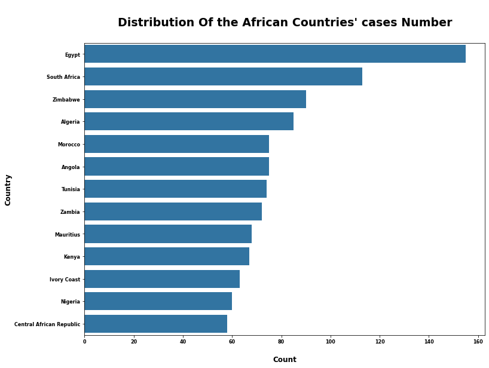

```python
plt.figure(figsize=(12,9))
base_color = sb.color_palette()[0]
country_order = cleaned_df['country'].value_counts().index
sb.countplot(data=cleaned_df, y='country', color=base_color, order=country_order);
plt.title("\nDistribution Of the African Countries' cases Number\n", fontsize=19, fontweight='bold')
plt.xlabel('\nCount', fontsize=12, fontweight='bold');
plt.ylabel('Country', fontsize=12, fontweight='bold');
plt.xticks(fontsize=8, fontweight='bold');
plt.yticks(fontsize=8, fontweight='bold');
```

- **Egypt** has the highest number of Cases, followed by **South Africa** and **Zimbabwe**.
- **Central African Republic, Nigeria** and **Ivory Coast** have the lowest number of cases in order.

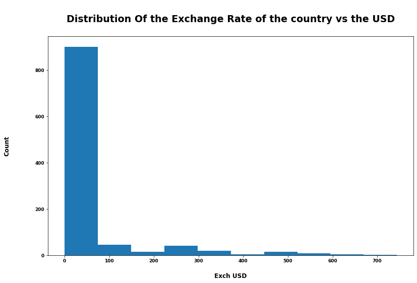

```python
plt.subplots(figsize=(13,8))
plt.hist(cleaned_df['exch_usd']);
plt.title('\nDistribution Of the Exchange Rate of the country vs the USD\n', fontsize=19, fontweight='bold');
plt.xlabel('\nExch USD', fontsize=12, fontweight='bold');
plt.ylabel('Count\n\n\n', fontsize=12, fontweight='bold');
plt.xticks(fontsize=9, fontweight='bold');
plt.yticks(fontsize=9, fontweight='bold');
```

```python
cleaned_df['exch_usd'].describe()
```

```
count    1055.000000
mean       43.298033
std       111.657299
min         0.000000
25%         0.195350
50%         0.898450
75%         8.485025
max       744.306139
Name: exch_usd, dtype: float64
```

- **Most exchange rates** of the countries are between **0 and 80** (The National Currency per USD).
- **50%** of cases the exchange rate is **0.9**.
- **In fewer cases** the exchange rates from **80 to 145 and from 230 to 290** come in second place.
- **The Fewest cases** are the exchange rates between **380 and 740**.

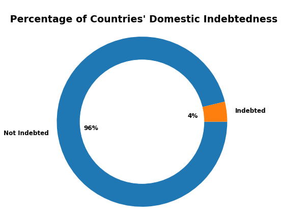

```python
plt.subplots(figsize=(15, 7))
domestic_dept = cleaned_df['domestic_debt_in_default'].value_counts()
plt.pie(domestic_dept, labels=domestic_dept.index, radius=1.1, counterclock=False, textprops={'fontsize' : 12, 'fontweight': 'bold'}, autopct='%1.0f%%');
plt.title("\n Percentage of Countries' Domestic Indebtedness", fontsize= 19, fontweight='bold')
circle=plt.Circle( (0,0), 0.8, color='white')
p=plt.gcf()
p.gca().add_artist(circle);
```

- **In 96% of the cases, countries are not Domestic indebted.**

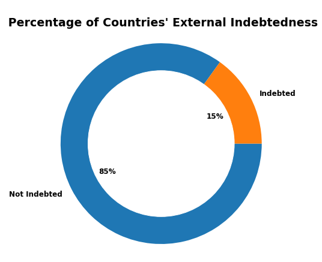

```python
plt.subplots(figsize=(15, 7))
external_dept = cleaned_df['sovereign_external_debt_default'].value_counts()
plt.pie(external_dept, labels=external_dept.index, radius=1.1, counterclock=False, textprops={'fontsize' : 12, 'fontweight': 'bold'}, autopct='%1.0f%%');
plt.title("\n Percentage of Countries' External Indebtedness", fontsize= 19, fontweight='bold')
circle=plt.Circle( (0,0), 0.8, color='white')
p=plt.gcf()
p.gca().add_artist(circle);
```

- **In 85% of the cases, countries are not external indebted.**
- **As shown, sovereign external debts are more than the domestic debts in the most cases.**

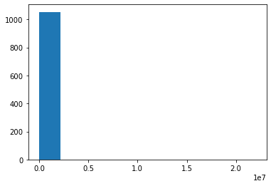

```python
plt.hist(x= cleaned_df['inflation_annual_cpi']);
```

```python
# I will use the percentile to shrink the outliers
# clipping any values higher than the 95th percentile
cleaned_df['inflation_annual_cpi'] = scipy.stats.mstats.winsorize(cleaned_df['inflation_annual_cpi'].values, limits=(0, 0.05))
```

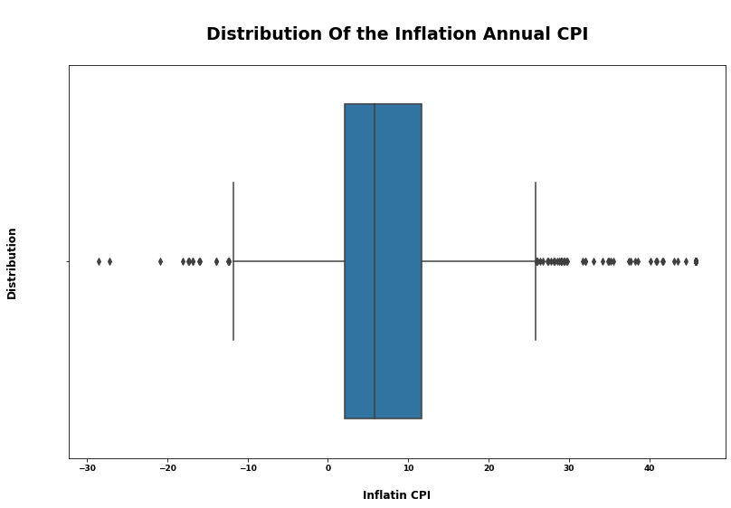

```python
plt.subplots(figsize=(13,8))
sb.boxplot(x=cleaned_df['inflation_annual_cpi']);
plt.title('\nDistribution Of the Inflation Annual CPI\n', fontsize=19, fontweight='bold');
plt.xlabel('\nInflatin CPI', fontsize=12, fontweight='bold');
plt.ylabel('Distribution\n\n\n', fontsize=12, fontweight='bold');
plt.xticks(fontsize=9, fontweight='bold');
plt.yticks(fontsize=9, fontweight='bold');
```

```python
cleaned_df['inflation_annual_cpi'].describe()
```

```
count    1055.000000
mean        8.757720
std        12.163218
min       -28.502137
25%         2.083333
50%         5.762330
75%        11.608813
max        45.714286
Name: inflation_annual_cpi, dtype: float64
```

**Note**: CPI is an indicator of inflation which measures the percentage change in the price of a basket of goods and services consumed by households.

- **The Inflation annual CPI in the most cases is high with the percentages between 2% and 12%.**
- **The negative percentages express the decreasing in the inflation indicator, the lowest percentage it reached was -28.5%**.

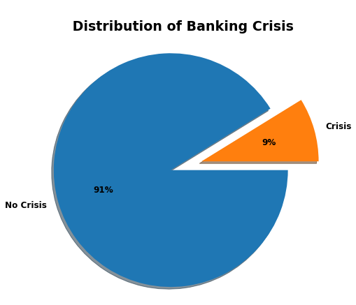

```python
plt.subplots(figsize=(15, 7))
banking_crises = cleaned_df['banking_crisis'].value_counts()
plt.pie(banking_crises, labels=banking_crises.index, radius=1.1, counterclock=False, textprops={'fontsize' : 12, 'fontweight': 'bold'}, shadow=True, explode=(0.1, 0.2), autopct='%1.0f%%');
plt.title('\n Distribution of Banking Crisis', fontsize=19, fontweight='bold');
```

- **There in no Banking Crisis in 91% of the cases**.

### Discuss the distribution(s) of your variable(s) of interest. Were there any unusual points? Did you need to perform any transformations?

> Yes there were unusual points like the outliers in the inflation_annual_cpi variable. I used the winsorization way to shrink the outliers and clip the values that higher than the 95th percentile.

### Of the features you investigated, were there any unusual distributions? Did you perform any operations on the data to tidy, adjust, or change the form of the data? If so, why did you do this?

> Yes i do some cleaning

## Bivariate Exploration

> In this section, investigate relationships between pairs of variables in your data. Make sure the variables that you cover here have been introduced in some fashion in the previous section (univariate exploration).

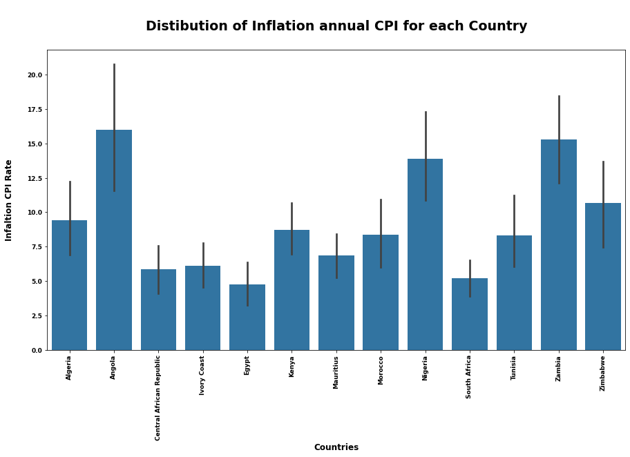

```python
plt.figure(figsize=(15,8))
sb.barplot(data=cleaned_df, x='country', y='inflation_annual_cpi', color=base_color);
plt.title('\nDistibution of Inflation annual CPI for each Country\n', fontsize=19, fontweight='bold');
plt.xlabel('Countries', fontsize=12, fontweight='bold')
plt.ylabel('Infaltion CPI Rate\n', fontsize=12, fontweight='bold');
plt.xticks(rotation=90, fontsize=9, fontweight='bold')
plt.yticks(fontsize=9, fontweight='bold');
```

- **Almost all the countries suffer from inflation at different rates.**
- **Angola**, **Zambia** and **Nigeria** have the **highest increasing in the Inflation annual CPI rate** in order.
- **Egypt** and **South Africa** have the **lowest increasing in the Inflation annual CPI rate**

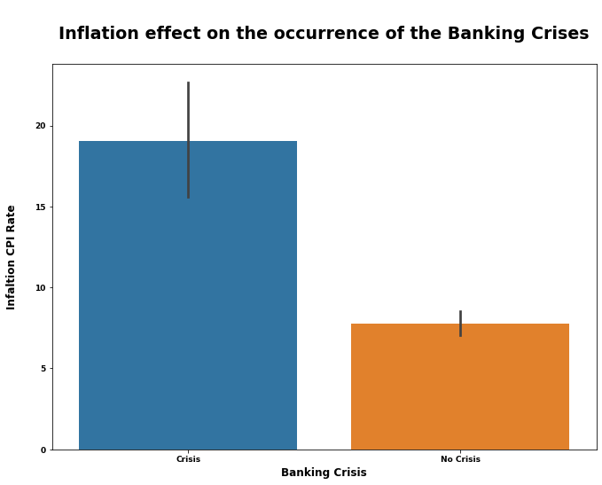

```python
plt.figure(figsize=(11,8))
sb.barplot(data=cleaned_df, x='banking_crisis', y='inflation_annual_cpi')
plt.title('\nInflation effect on the occurrence of the Banking Crises\n', fontsize=19, fontweight='bold')
plt.xlabel('Banking Crisis', fontsize=12, fontweight='bold')
plt.ylabel('Infaltion CPI Rate\n', fontsize=12, fontweight='bold');
plt.xticks(fontsize=9, fontweight='bold')
plt.yticks(fontsize=9, fontweight='bold');
```

- **It is obvious that the increasing in the inflation rates cause increasing in the probability of the banking crisis occurrence.**

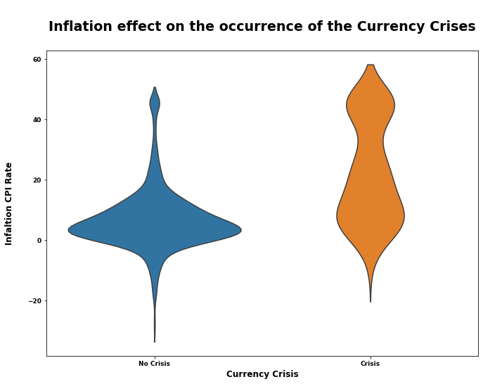

```python
plt.figure(figsize=(11,8))
sb.violinplot(data=cleaned_df, x='currency_crises', y='inflation_annual_cpi', inner = None)
plt.title('\nInflation effect on the occurrence of the Currency Crises\n', fontsize=19, fontweight='bold')
plt.xlabel('Currency Crisis', fontsize=12, fontweight='bold')
plt.ylabel('Infaltion CPI Rate\n', fontsize=12, fontweight='bold');
plt.xticks(fontsize=9, fontweight='bold')
plt.yticks(fontsize=9, fontweight='bold');
```

- **According to the distributions, when the Inflation CPI rate is close to or equal zero, The incidence of currency crisis is much lower than the no crisis cases.**
- **The increasing in the inflation rate cause increasing in the currency crisis.**

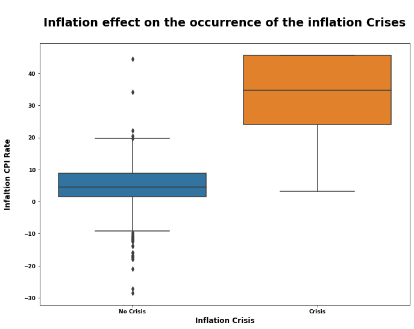

```python
plt.figure(figsize=(11,8))
sb.boxplot(data=cleaned_df, x='inflation_crises', y='inflation_annual_cpi')
plt.title('\nInflation effect on the occurrence of the inflation Crises\n', fontsize=19, fontweight='bold')
plt.xlabel('Inflation Crisis', fontsize=12, fontweight='bold')
plt.ylabel('Infaltion CPI Rate\n', fontsize=12, fontweight='bold');
plt.xticks(fontsize=9, fontweight='bold')
plt.yticks(fontsize=9, fontweight='bold');
```

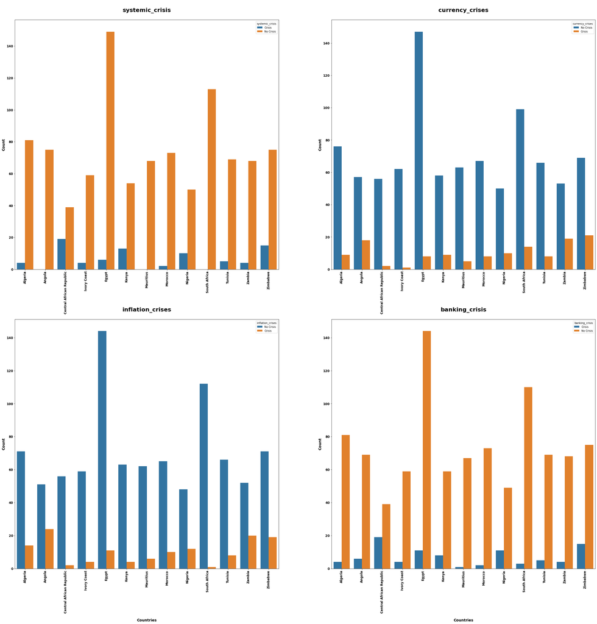

```python
columns = ['systemic_crisis', 'currency_crises', 'inflation_crises', 'banking_crisis']
plt.figure(figsize=(40, 60))
plot = 1
for col in columns:
    plt.subplot(3,2,plot)
    plot +=1
    sb.countplot(x=cleaned_df['country'], hue=cleaned_df[col])
    plt.title('\n'+col+'\n',fontsize=22, fontweight='bold')
    plt.xlabel('\nCountries', fontsize=14, fontweight='bold')
    plt.ylabel('Count', fontsize=14, fontweight='bold');
    plt.xticks(rotation=90,fontsize=12, fontweight='bold')
    plt.yticks(fontsize=12, fontweight='bold');
```

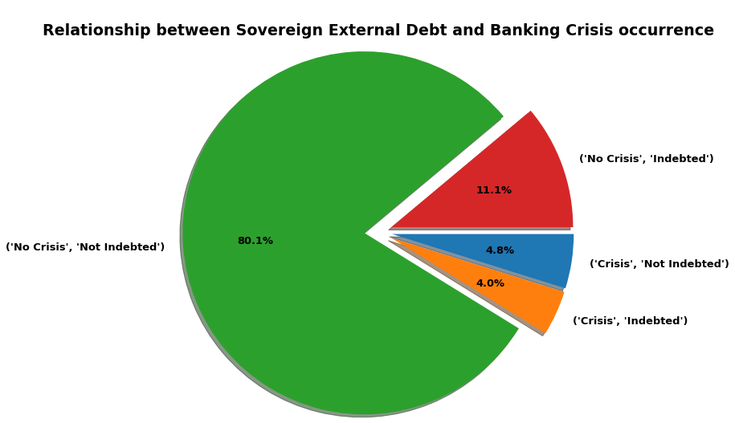

```python
external_debt_effect = cleaned_df.groupby('banking_crisis')['sovereign_external_debt_default'].value_counts()
plt.subplots(figsize=(14, 8));
plt.pie(external_debt_effect, labels=external_debt_effect.index, autopct = "%1.1f%%", radius=1.3,counterclock=False , textprops={'fontsize': 13 , 'fontweight' : 'bold'}, shadow=True, explode=(0.1, 0.1, 0.1, 0.1));
plt.title('\nRelationship between Sovereign External Debt and Banking Crisis occurrence\n', fontsize=19, fontweight='bold')
plt.xticks(fontsize=11 ,fontweight='bold');
plt.yticks( fontsize=11 ,fontweight='bold');
```

- **The percentage of both No Crisis and Not Indebted cases is 80.1%, while the percentage of the country is being Indebted and there is no crisis is 11.1% and it's higher than the banking crisis occurrence while the country isn't Indebted which is 4.8%**

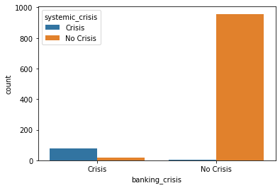

```python
sb.countplot(x=cleaned_df['banking_crisis'], hue=cleaned_df['systemic_crisis']);
```

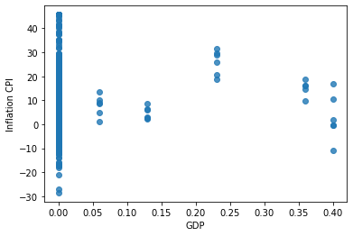

```python
sb.regplot(data = cleaned_df, x = 'gdp_weighted_default', y = 'inflation_annual_cpi', fit_reg = False);
plt.xlabel('GDP')
plt.ylabel('Inflation CPI');
```

### Talk about some of the relationships you observed in this part of the investigation. How did the feature(s) of interest vary with other features in the dataset?

> According to the different distributions, there is a strong relationship between the increasing of inflation CPI and the occurrence of various crises (Inflation Crises, Currency Crisis) and it's clearly shown in the relationship between the african countries with the inflation CPI rate and the different crises.

### Did you observe any interesting relationships between the other features (not the main feature(s) of interest)?

> Yes, The relationship between countries and the various crises. The No crisis cases is much higher than the crisis occurrence cases.

> There is a strong relationship between systemic and banking crisis more than the inflation CPI rate and the banking crisis.

> The relationship between that the country is being Sovereign External Indebted and the Banking crisis occurrence is not that strong.

## Multivariate Exploration

> Create plots of three or more variables to investigate your data even further. Make sure that your investigations are justified, and follow from your work in the previous sections.

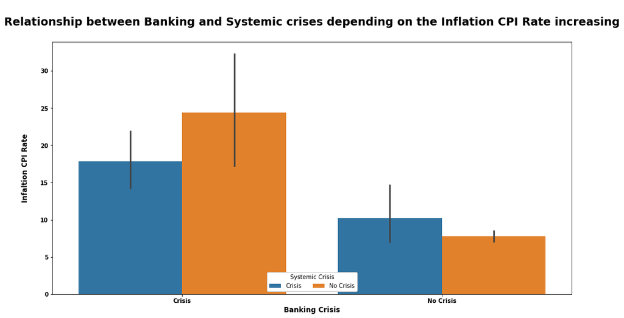

```python
plt.figure(figsize=(16,8))
ax = sb.barplot(x=cleaned_df['banking_crisis'], y=cleaned_df['inflation_annual_cpi'], hue=cleaned_df['systemic_crisis']);
ax.legend(loc = 8, ncol = 3, framealpha = 1, title = 'Systemic Crisis');
plt.title('\nRelationship between Banking and Systemic crises depending on the Inflation CPI Rate increasing\n', fontsize=19, fontweight='bold')
plt.xlabel('Banking Crisis', fontsize=12, fontweight='bold')
plt.ylabel('Infaltion CPI Rate\n', fontsize=12, fontweight='bold');
plt.xticks(fontsize=10, fontweight='bold')
plt.yticks(fontsize=10, fontweight='bold');
```

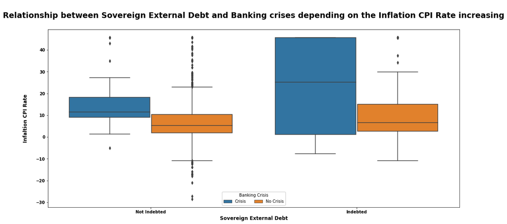

```python
plt.figure(figsize=(18,8))
ax = sb.boxplot(x="sovereign_external_debt_default", y="inflation_annual_cpi", hue="banking_crisis", data=cleaned_df);
ax.legend(loc = 8, ncol = 3, framealpha = 1, title = 'Banking Crisis');
plt.title('\nRelationship between Sovereign External Debt and Banking crises depending on the Inflation CPI Rate increasing\n', fontsize=19, fontweight='bold')
plt.xlabel('Sovereign External Debt', fontsize=12, fontweight='bold')
plt.ylabel('Infaltion CPI Rate\n', fontsize=12, fontweight='bold');
plt.xticks(fontsize=10, fontweight='bold')
plt.yticks(fontsize=10, fontweight='bold');
```

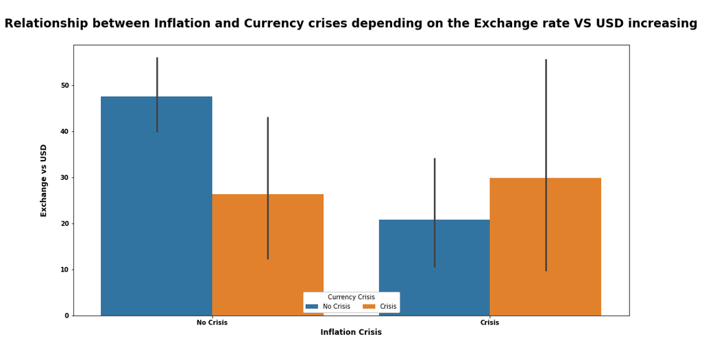

```python
plt.figure(figsize=(16,8))
ax = sb.barplot(x=cleaned_df['inflation_crises'], y=cleaned_df['exch_usd'], hue=cleaned_df['currency_crises']);
ax.legend(loc = 8, ncol = 3, framealpha = 1, title = 'Currency Crisis');
plt.title('\nRelationship between Inflation and Currency crises depending on the Exchange rate VS USD increasing\n', fontsize=19, fontweight='bold')
plt.xlabel('Inflation Crisis', fontsize=12, fontweight='bold')
plt.ylabel('Exchange vs USD\n', fontsize=12, fontweight='bold');
plt.xticks(fontsize=10, fontweight='bold')
plt.yticks(fontsize=10, fontweight='bold');
```

- **During the increasing of the exchange rate vs the USD, The No Currency crisis cases is higher than the crisis occurrence, but in the Inflation Crisis occurrence we can see that the Currency Crisis Occurrence is higher than the No Currency cisis cases.**
- **The Inflation Crisis occurrence affects on the occurence and the increasing in the Currency Crisis occurrence.**

### Talk about some of the relationships you observed in this part of the investigation. Were there features that strengthened each other in terms of looking at your feature(s) of interest?

> In this part of exploration we discovered strong relationships between different features like (The Sovereign External Debt and Banking Crisis) and (The Inflation and Currency Crises)

### Were there any interesting or surprising interactions between features?

> We found out that other relationships is not that strong like ( The banking and Systemic crises)

## Resources

- https://www.kaggle.com/chirin/africa-economic-banking-and-systemic-crisis-data
- https://classroom.udacity.com/nanodegrees/nd002-mena-nfp3/parts/211104e3-a5bc-4247-87b7-06bfa757806c __(Udacity Data Visualization Course)
- https://seaborn.pydata.org/generated/seaborn.boxplot.html
- https://www.kaggle.com/miltonsuggs/03-africa-economics